# error checking the LE decomp functions

Corinne Riddell

September 22, 2016

In this file we apply the functions created to calculate and decompose life expectancy by way of example, and as a way to cross-check against results from published findings (to ensure my functions work properly).

Our functions:

```r
library(dplyr)
```

```r
library(ggplot2)
source("/Users/corinneriddell/Documents/repos/BlackWhiteMortalityGap/Code/life_expectancy_functions.R")
```

**First example**

We use data from a paper published by Auger et al and compare our findings to those found by the authors.

Here is the data need to calculate life expectancy, as provided by the authors in a supplementary appendix (xls file) to their paper:

```r
canada.men <- data.frame("ages" = c(0, 1, 5, 10, 15, 20, 25, 30, 35, 40, 45, 50, 55, 60, 65, 70, 75, 80, 85, 90),
                         "obs.deaths" = c(4054, 625, 445, 622, 2568, 3770, 3434, 3681, 5155, 8449, 13421, 19371,
                                          25448, 31465, 37441, 48796, 64763, 72512, 60109, 43812),
                         "obs.popn" = c(719953, 2835604, 3654546, 4071400, 4464549, 4564679, 4296613, 4237402,
                                        4532151, 5085092, 5163532, 4597916, 3937984, 3120981, 2323629, 1862971,
                                        1499907, 997492, 492445, 196109))

quebec.men <- data.frame("ages" = c(0, 1, 5, 10, 15, 20, 25, 30, 35, 40, 45, 50, 55, 60, 65, 70, 75, 80, 85, 90),
                         "obs.deaths" = c(1057, 164, 116, 176, 659, 956, 1056, 1110, 1498, 2470, 4116, 6054, 8426,
                                          11175, 13558, 16567, 21349, 22396, 16851,10878),
                         "obs.popn" = c(215200, 789710, 1008266, 1179423, 1249360, 1261780, 1349857, 1293521,
                                        1313834, 1551684, 1622835, 1485249, 1288014, 1077253, 796557, 609341,
                                        476211, 300506, 134353, 49678))
```

I then add a column that denotes how many years are in each age bracket:

```r
canada.men$n_x <- 5
canada.men$n_x[canada.men$ages == 0] <- 1
canada.men$n_x[canada.men$ages == 1] <- 4

quebec.men$n_x <- 5
quebec.men$n_x[quebec.men$ages == 0] <- 1
quebec.men$n_x[quebec.men$ages == 1] <- 4

head(canada.men)
```

```
##   ages obs.deaths obs.popn n_x
## 1    0       4054   719953   1
## 2    1        625  2835604   4
## 3    5        445  3654546   5
## 4   10        622  4071400   5
## 5   15       2568  4464549   5
## 6   20       3770  4564679   5
```

```r
head(quebec.men)
```

```
##   ages obs.deaths obs.popn n_x
## 1    0       1057   215200   1
## 2    1        164   789710   4
## 3    5        116  1008266   5
## 4   10        176  1179423   5
## 5   15        659  1249360   5
## 6   20        956  1261780   5
```

We also need data on the proportion of deaths within each age bracket due to each cause of death.

```r
cod.props <- read.csv("/Users/corinneriddell/Documents/repos/BlackWhiteMortalityGap/working_teaching_examples/auger_cod_proportions.csv")
names(cod.props)[3] <- "prop.QC"
names(cod.props)[4] <- "prop.CAD"
head(cod.props)
```

```
##      Age           cod     prop.QC    prop.CAD age.lower
## 1     <1 neoplasms.lip 0.000000000 0.000000000         0
## 2 04-Jan neoplasms.lip 0.000000000 0.001600000         1
## 3 09-May neoplasms.lip 0.000000000 0.000000000         5
## 4 14-Oct neoplasms.lip 0.005681818 0.000000000        10
## 5  15-19 neoplasms.lip 0.001517451 0.000389408        15
## 6  20-24 neoplasms.lip 0.000000000 0.001591512        20
```

Calculate and display the life tables for the Canada and Quebec data:

```r
life.table.cm <- life.table(data = canada.men, num.ages.in.group = "n_x",
                            death.counts = "obs.deaths", population.counts = "obs.popn")

round(life.table.cm, 2)
```

```
##    ages obs.deaths obs.popn n_x  R_x  a_x  q_x  p_x       l_x      d_x
## 1     0       4054   719953   1 0.01 0.09 0.01 0.99 100000.00   560.22
## 2     1        625  2835604   4 0.00 0.50 0.00 1.00  99439.78    87.63
## 3     5        445  3654546   5 0.00 0.50 0.00 1.00  99352.15    60.47
## 4    10        622  4071400   5 0.00 0.50 0.00 1.00  99291.68    75.82
## 5    15       2568  4464549   5 0.00 0.50 0.00 1.00  99215.86   284.93
## 6    20       3770  4564679   5 0.00 0.50 0.00 1.00  98930.93   407.70
## 7    25       3434  4296613   5 0.00 0.50 0.00 1.00  98523.23   392.93
## 8    30       3681  4237402   5 0.00 0.50 0.00 1.00  98130.30   425.30
## 9    35       5155  4532151   5 0.00 0.50 0.01 0.99  97705.00   554.09
## 10   40       8449  5085092   5 0.00 0.50 0.01 0.99  97150.91   803.75
## 11   45      13421  5163532   5 0.00 0.50 0.01 0.99  96347.16  1244.04
## 12   50      19371  4597916   5 0.00 0.50 0.02 0.98  95103.12  1982.46
## 13   55      25448  3937984   5 0.01 0.50 0.03 0.97  93120.65  2960.98
## 14   60      31465  3120981   5 0.01 0.50 0.05 0.95  90159.67  4433.11
```

[output cut: 27 more lines]

```r
life.table.qm <- life.table(data = quebec.men, num.ages.in.group = "n_x",
                            death.counts = "obs.deaths", population.counts = "obs.popn")

round(life.table.qm, 2)
```

```
##    ages obs.deaths obs.popn n_x  R_x  a_x  q_x  p_x       l_x      d_x
## 1     0       1057   215200   1 0.00 0.09 0.00 1.00 100000.00   488.99
## 2     1        164   789710   4 0.00 0.50 0.00 1.00  99511.01    82.63
## 3     5        116  1008266   5 0.00 0.50 0.00 1.00  99428.39    57.18
## 4    10        176  1179423   5 0.00 0.50 0.00 1.00  99371.21    74.12
## 5    15        659  1249360   5 0.00 0.50 0.00 1.00  99297.09   261.54
## 6    20        956  1261780   5 0.00 0.50 0.00 1.00  99035.56   374.47
## 7    25       1056  1349857   5 0.00 0.50 0.00 1.00  98661.09   385.16
## 8    30       1110  1293521   5 0.00 0.50 0.00 1.00  98275.93   420.76
## 9    35       1498  1313834   5 0.00 0.50 0.01 0.99  97855.16   556.27
## 10   40       2470  1551684   5 0.00 0.50 0.01 0.99  97298.89   771.34
## 11   45       4116  1622835   5 0.00 0.50 0.01 0.99  96527.55  1216.40
## 12   50       6054  1485249   5 0.00 0.50 0.02 0.98  95311.15  1922.89
## 13   55       8426  1288014   5 0.01 0.50 0.03 0.97  93388.26  3005.51
## 14   60      11175  1077253   5 0.01 0.50 0.05 0.95  90382.75  4569.47
```

[output cut: 27 more lines]

Life expectancy at birth in Canadian men is 78.51 vs. 78.42 in Quebec men, for a life expectancy gap of 0.0897623 years.

Decompose the life expectancy gap by age:

```r
age_decomp <- le_age_decomp(life.table1 = life.table.qm, name.lt1 = "Quebec",
                            life.table2 = life.table.cm, name.lt2 = "Canada",
                            age.groups = "ages")
age_decomp
```

```
##    Ages LE_Quebec LE_Canada           C_x adds_to_gap
## 1     0 78.420088 78.509850 -0.0561780837       FALSE
## 2     1 77.804993 77.951650 -0.0038517971       FALSE
## 3     5 73.867989 74.018642 -0.0023883160       FALSE
## 4    10 68.909055 69.062198 -0.0011732307       FALSE
## 5    15 63.958623 64.113062 -0.0146017639       FALSE
## 6    20 59.120925 59.290516 -0.0191953945       FALSE
## 7    25 54.335829 54.525520 -0.0043449647       FALSE
## 8    30 49.538984 49.733839 -0.0024532884       FALSE
## 9    35 44.741244 44.939444  0.0005700879        TRUE
## 10   40 39.982744 40.181491 -0.0127805672       FALSE
## 11   45 35.282265 35.495841 -0.0100168690       FALSE
## 12   50 30.700646 30.927457 -0.0185560990       FALSE
## 13   55 26.281304 26.532655  0.0089404115        TRUE
## 14   60 22.072107 22.321924  0.0261406140        TRUE
## 15   65 18.114302 18.346960  0.0616768138        TRUE
## 16   70 14.502195 14.677271  0.0478767430        TRUE
## 17   75 11.252786 11.383787  0.0509032158        TRUE
## 18   80  8.462415  8.533790  0.0312884341        TRUE
## 19   85  6.192998  6.213989  0.0257556445        TRUE
## 20   90  4.566832  4.476148 -0.0178492500       FALSE
```

```r
sum(age_decomp$C_x)
```

```
## [1] 0.08976234
```

Check that the function still works when the life tables are provided in the reverse order:

```r
age_decomp2 <- le_age_decomp(life.table1 = life.table.cm, name.lt1 = "Canada",
                             life.table2 = life.table.qm, name.lt2 = "Quebec",
                             age.groups = "ages")
age_decomp2
```

```
##    Ages LE_Canada LE_Quebec           C_x adds_to_gap
## 1     0 78.509850 78.420088  0.0560736104        TRUE
## 2     1 77.951650 77.804993  0.0038414117        TRUE
## 3     5 74.018642 73.867989  0.0023813775        TRUE
## 4    10 69.062198 68.909055  0.0011695738        TRUE
## 5    15 64.113062 63.958623  0.0145497753        TRUE
## 6    20 59.290516 59.120925  0.0191113303        TRUE
## 7    25 54.525520 54.335829  0.0043227075        TRUE
## 8    30 49.733839 49.538984  0.0024394185        TRUE
## 9    35 44.939444 44.741244 -0.0005665625       FALSE
## 10   40 40.181491 39.982744  0.0126893986        TRUE
## 11   45 35.495841 35.282265  0.0099303099        TRUE
## 12   50 30.927457 30.700646  0.0183552981        TRUE
## 13   55 26.532655 26.281304 -0.0088250703       FALSE
## 14   60 22.321924 22.072107 -0.0257850774       FALSE
## 15   65 18.346960 18.114302 -0.0609864907       FALSE
## 16   70 14.677271 14.502195 -0.0475929318       FALSE
## 17   75 11.383787 11.252786 -0.0510074849       FALSE
## 18   80  8.533790  8.462415 -0.0317451127       FALSE
## 19   85  6.213989  6.192998 -0.0267881392       FALSE
## 20   90  4.476148  4.566832  0.0186703173        TRUE
```

```r
sum(age_decomp2$C_x)
```

```
## [1] -0.08976234
```

Compare the output of the above two functions – the contribution of age to the LE gap are slightly different based on the order of operation:

```r
round(cbind(age_decomp$C_x, age_decomp2$C_x),4)
```

```
##          [,1]    [,2]
##  [1,] -0.0562  0.0561
##  [2,] -0.0039  0.0038
##  [3,] -0.0024  0.0024
##  [4,] -0.0012  0.0012
##  [5,] -0.0146  0.0145
##  [6,] -0.0192  0.0191
##  [7,] -0.0043  0.0043
##  [8,] -0.0025  0.0024
##  [9,]  0.0006 -0.0006
## [10,] -0.0128  0.0127
## [11,] -0.0100  0.0099
## [12,] -0.0186  0.0184
## [13,]  0.0089 -0.0088
## [14,]  0.0261 -0.0258
## [15,]  0.0617 -0.0610
## [16,]  0.0479 -0.0476
## [17,]  0.0509 -0.0510
## [18,]  0.0313 -0.0317
## [19,]  0.0258 -0.0268
## [20,] -0.0178  0.0187
```

```r
canada.cod.decomp <- cause_of_death_decomp(life.table1 = life.table.qm,
                                           life.table2 = life.table.cm,
                                           decomp.table = age_decomp,
                                           cod.table = cod.props,
                                           age.colname.cod.table = "Age",
                                           COD.colname.cod.table = "cod",
                                           prop1.colname.cod.table = "prop.QC",
                                           prop2.colname.cod.table = "prop.CAD")
```

Collapse by cause of death to calculate the overall contribution of each cause of death to the gap in life expectnancy:

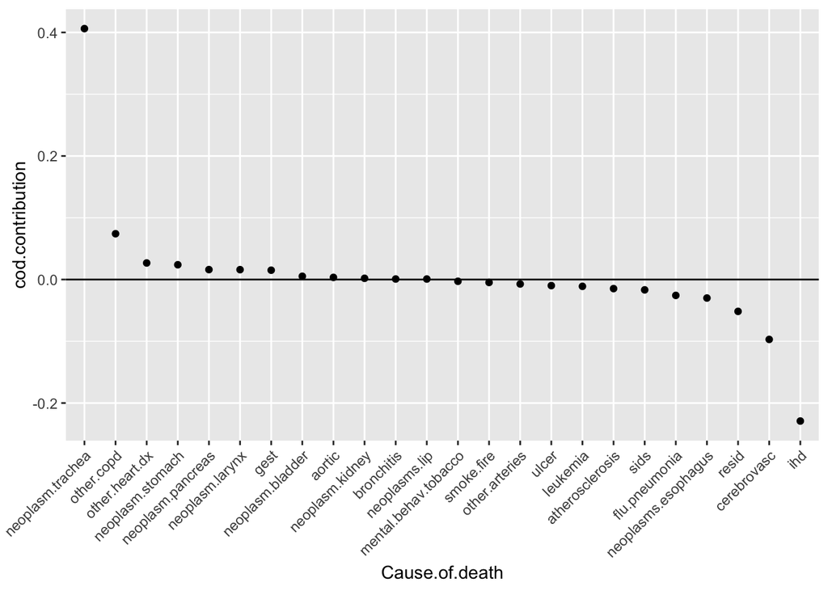

```r
cod.contribution <- canada.cod.decomp %>%
  group_by(Cause.of.death) %>%
  summarise(cod.contribution = sum(C_xi))

#order by contribution amount for graphing purposes
cod.contribution$Cause.of.death <- factor(cod.contribution$Cause.of.death,
                                          levels = cod.contribution$Cause.of.death[order(cod.contribution$cod.contribution,
                                                                                         decreasing = T)])

ggplot(cod.contribution, aes(x = Cause.of.death, y = cod.contribution)) +
  geom_point() +
  theme(axis.text.x = element_text(angle = 45, hjust = 1)) +
  geom_abline(intercept = 0, slope = 0)
```

Collapse by age and confirm these line up with the marginal age decomposition:

```r
age.contribution <- canada.cod.decomp %>% group_by(Ages) %>% summarise(age.contribution = sum(C_xi))

age.contribution
```

```
## Source: local data frame [20 x 2]
##
##      Ages age.contribution
##    (fctr)            (dbl)
## 1      <1    -0.0561780842
## 2  04-Jan    -0.0038517971
## 3  09-May    -0.0023883159
## 4  14-Oct    -0.0011732307
## 5   15-19    -0.0146017634
## 6   20-24    -0.0191953949
## 7   25-29    -0.0043449645
## 8   30-34    -0.0024532878
## 9   35-39     0.0005700881
## 10  40-44    -0.0127805690
## 11  45-49    -0.0100168698
## 12  50-54    -0.0185560995
## 13  55-59     0.0089404130
## 14  60-64     0.0261406140
## 15  65-69     0.0616768126
## 16  70-74     0.0478767405
## 17  75-79     0.0509032171
## 18  80-84     0.0312884353
## 19  85-89     0.0257556445
## 20     90    -0.0178492747
```

**A second example**

In this example we use the data that Sam entered into Stata to illustrate the life expectancy concept to me. I’ll replicate the life table here to ensure that I can arrive at the same results as he does in Stata.

```r
cali.complete <- data.frame("ages" = c(0:15), "nx" = rep(1,16),
                         "obs.deaths" = c(1635, 64, 41, 22, 41, 55, 42, 58, 44, 52, 48, 60, 52, 82, 129, 23300), #last number is fictitious
                         "obs.popn" = c(123342, 111520, 109200, 108749, 105698, 110548, 106857, 112184, 116423,
                                        132952, 134266, 128938, 125502, 128212, 132775, 143600))

head(cali.complete)
```

```
##   ages nx obs.deaths obs.popn
## 1    0  1       1635   123342
## 2    1  1         64   111520
## 3    2  1         41   109200
## 4    3  1         22   108749
## 5    4  1         41   105698
## 6    5  1         55   110548
```

```r
life.table(data = cali.complete, num.ages.in.group = "nx",
           death.counts = "obs.deaths", population.counts = "obs.popn")
```

```
##    ages nx obs.deaths obs.popn          R_x  a_x          q_x       p_x
## 1     0  1       1635   123342 0.0132558253 0.09 0.0130978288 0.9869022
## 2     1  1         64   111520 0.0005738881 0.50 0.0005737235 0.9994263
## 3     2  1         41   109200 0.0003754579 0.50 0.0003753874 0.9996246
## 4     3  1         22   108749 0.0002023007 0.50 0.0002022803 0.9997977
## 5     4  1         41   105698 0.0003878976 0.50 0.0003878224 0.9996122
## 6     5  1         55   110548 0.0004975214 0.50 0.0004973977 0.9995026
## 7     6  1         42   106857 0.0003930487 0.50 0.0003929714 0.9996070
## 8     7  1         58   112184 0.0005170078 0.50 0.0005168742 0.9994831
## 9     8  1         44   116423 0.0003779322 0.50 0.0003778608 0.9996221
## 10    9  1         52   132952 0.0003911186 0.50 0.0003910421 0.9996090
## 11   10  1         48   134266 0.0003574993 0.50 0.0003574354 0.9996426
## 12   11  1         60   128938 0.0004653399 0.50 0.0004652317 0.9995348
## 13   12  1         52   125502 0.0004143360 0.50 0.0004142502 0.9995857
## 14   13  1         82   128212 0.0006395657 0.50 0.0006393613 0.9993606
```

[output cut: 19 more lines]

```r
cali.complete$avelived <- 0.5
cali.complete$avelived[cali.complete$ages==0] <- 0.1

life.table(data = cali.complete, num.ages.in.group = "nx", ave.prop.lived = "avelived",
           death.counts = "obs.deaths", population.counts = "obs.popn")
```

```
##    ages nx obs.deaths obs.popn avelived          R_x a_x          q_x
## 1     0  1       1635   123342      0.1 0.0132558253 0.1 0.0130995445
## 2     1  1         64   111520      0.5 0.0005738881 0.5 0.0005737235
## 3     2  1         41   109200      0.5 0.0003754579 0.5 0.0003753874
## 4     3  1         22   108749      0.5 0.0002023007 0.5 0.0002022803
## 5     4  1         41   105698      0.5 0.0003878976 0.5 0.0003878224
## 6     5  1         55   110548      0.5 0.0004975214 0.5 0.0004973977
## 7     6  1         42   106857      0.5 0.0003930487 0.5 0.0003929714
## 8     7  1         58   112184      0.5 0.0005170078 0.5 0.0005168742
## 9     8  1         44   116423      0.5 0.0003779322 0.5 0.0003778608
## 10    9  1         52   132952      0.5 0.0003911186 0.5 0.0003910421
## 11   10  1         48   134266      0.5 0.0003574993 0.5 0.0003574354
## 12   11  1         60   128938      0.5 0.0004653399 0.5 0.0004652317
## 13   12  1         52   125502      0.5 0.0004143360 0.5 0.0004142502
## 14   13  1         82   128212      0.5 0.0006395657 0.5 0.0006393613
```

[output cut: 36 more lines]

```r
cali.complete$group <- cut(cali.complete$ages, breaks=c(0, 1, 5, 10, 15, 20),
                           labels = c("<1 years old", "1-4 years old", "5-9 years old",
                                      "10-14 years old", "15 or older"), include.lowest = T, right = F)

table(cali.complete$group, cali.complete$ages)
```

```
##
##                   0 1 2 3 4 5 6 7 8 9 10 11 12 13 14 15
##   <1 years old    1 0 0 0 0 0 0 0 0 0  0  0  0  0  0  0
##   1-4 years old   0 1 1 1 1 0 0 0 0 0  0  0  0  0  0  0
##   5-9 years old   0 0 0 0 0 1 1 1 1 1  0  0  0  0  0  0
##   10-14 years old 0 0 0 0 0 0 0 0 0 0  1  1  1  1  1  0
##   15 or older     0 0 0 0 0 0 0 0 0 0  0  0  0  0  0  1
```

```r
cali.abridged <- cali.complete %>% group_by(group) %>%
                                   summarise(nx = sum(nx), ages = first(group), popn = sum(obs.popn), deaths = sum(obs.deaths),
                                             avelived = first(avelived))

cali.abridged
```

```
## Source: local data frame [5 x 6]
##
##             group    nx            ages   popn deaths avelived
##            (fctr) (dbl)          (fctr)  (dbl)  (dbl)    (dbl)
## 1    <1 years old     1    <1 years old 123342   1635      0.1
## 2   1-4 years old     4   1-4 years old 435167    168      0.5
## 3   5-9 years old     5   5-9 years old 578964    251      0.5
## 4 10-14 years old     5 10-14 years old 649693    371      0.5
## 5     15 or older     1     15 or older 143600  23300      0.5
```

```r
data.frame(life.table(data = cali.abridged, num.ages.in.group = "nx",
           death.counts = "deaths", population.counts = "popn"))
```

```
##             group nx            ages   popn deaths avelived          R_x
## 1    <1 years old  1    <1 years old 123342   1635      0.1 0.0132558253
## 2   1-4 years old  4   1-4 years old 435167    168      0.5 0.0003860587
## 3   5-9 years old  5   5-9 years old 578964    251      0.5 0.0004335330
## 4 10-14 years old  5 10-14 years old 649693    371      0.5 0.0005710389
## 5     15 or older  1     15 or older 143600  23300      0.5 0.1622562674
##    a_x         q_x       p_x       l_x        d_x      L_x    cumsum
## 1 0.09 0.013097829 0.9869022 100000.00  1309.7829  98808.1   98808.1
## 2 0.50 0.001543043 0.9984570  98690.22   152.2833 394456.3  493264.4
## 3 0.50 0.002165318 0.9978347  98537.93   213.3660 492156.3  985420.7
## 4 0.50 0.002851124 0.9971489  98324.57   280.3356 490922.0 1476342.7
## 5 0.50 1.000000000 0.0000000  98044.23 98044.2323 604255.4 2080598.1
##    l.cumsum       T_x      e_x
## 1       0.0 2080598.1 20.80598
## 2   98808.1 1981790.0 20.08092
## 3  493264.4 1587333.7 16.10886
## 4  985420.7 1095177.4 11.13839
## 5 1476342.7  604255.4  6.16309
```

```r
data.frame(life.table(data = cali.abridged, num.ages.in.group = "nx",
           death.counts = "deaths", population.counts = "popn", ave.prop.lived = "avelived"))
```

```
##             group nx            ages   popn deaths avelived          R_x
## 1    <1 years old  1    <1 years old 123342   1635      0.1 0.0132558253
## 2   1-4 years old  4   1-4 years old 435167    168      0.5 0.0003860587
## 3   5-9 years old  5   5-9 years old 578964    251      0.5 0.0004335330
## 4 10-14 years old  5 10-14 years old 649693    371      0.5 0.0005710389
## 5     15 or older  1     15 or older 143600  23300      0.5 0.1622562674
##   a_x         q_x       p_x       l_x        d_x       L_x     cumsum
## 1 0.1 0.013099545 0.9869005 100000.00  1309.9545  98821.04   98821.04
## 2 0.5 0.001543043 0.9984570  98690.05   152.2830 394455.62  493276.66
## 3 0.5 0.002165318 0.9978347  98537.76   213.3656 492155.40  985432.06
## 4 0.5 0.002851124 0.9971489  98324.40   280.3351 490921.15 1476353.20
## 5 0.5 1.000000000 0.0000000  98044.06 98044.0618 604254.39 2080607.59
##     l.cumsum       T_x      e_x
## 1       0.00 2080607.6 20.80608
## 2   98821.04 1981786.6 20.08092
## 3  493276.66 1587330.9 16.10886
## 4  985432.06 1095175.5 11.13839
## 5 1476353.20  604254.4  6.16309
```